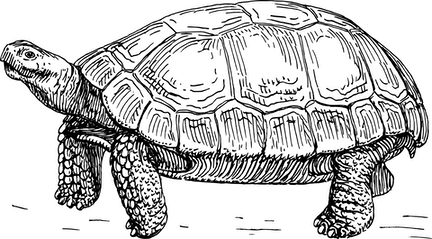

## Designcraft for experiments open data

A set of remote exercises exploring experimental design for the life sciences. A total of three independent labs were done to focus on different design principles, sampling techniques, and taxa. Exercises are described in full in this open access manual entitled [Designcraft for experiments](https://bookdown.org/chris/designcraft4experiments/). Data were collected by students in a third-year biology course offering at [York University](https://biology.yorku.ca) in Toronto, ON, Canada. Students collected the data and published individual datasets to [figshare](https://figshare.com) with a [CCBY4.0](https://creativecommons.org/licenses/by/4.0/) licensing. Data were then compiled for each lab including balcony birdwatching, backyard bioblitz, and solo surveys by M. Zuliani (ORCID: 0000-0001-8114-3609) and M. Owen (ORCID: 0000-0002-9931-4522). The provenance of each independent observation in the compiled data was recognized by attribution to the initials of the primary data author including citation via DOI and link to figshare.

Attribution  
CJL designed the experiments.  
Students in course offering collected, innovated, and published individual, primary datasets.  
MZ, MO, and CJL reviewed the compiled data.

Metadata  
Record-level  
year is the calendar year of work not term  
experiment describes the three experimental options in designcraft book  
source is either full experiment or pilot experiment  
rep is the replicate per experimental set  
location is the site name locally  
habitat is the ecological classification  
date is the calendar date for each observation

Attribute-level  
bioblitz  
taxa is a classification by vertebrate or invertebrate  
species in the genus and species for observation

birds  
frequency is the number observed within a 3-5min observation interval  
behaviours are described in ethogram

solo-survey  
vegetation surveys and species_richness is the total number of unique species observed per 0.5 x 0.5m quadrat  
total cover is the total cover of vegetation within the 0.5m quadrat capped at 100

### Data

Data checks

```r
library(tidyverse)
library(skimr)
library(lubridate)

#bioblitz
bioblitz <- read_csv("data/2021/designcraft4expts_bioblitz2021.csv") %>%
  mutate(date = mdy(date))
problems(bioblitz)
```

```
## # A tibble: 0 × 5
## # … with 5 variables: row <int>, col <int>, expected <chr>, actual <chr>,
## #   file <chr>
```

```r
str(bioblitz)
```

```
## spec_tbl_df [236 × 12] (S3: spec_tbl_df/tbl_df/tbl/data.frame)
##  $ year        : num [1:236] 2021 2021 2021 2021 2021 ...
##  $ experiment  : chr [1:236] "bioblitz" "bioblitz" "bioblitz" "bioblitz" ...
##  $ source      : chr [1:236] "full" "full" "full" "full" ...
##  $ rep         : num [1:236] 1 2 3 4 5 6 7 8 9 10 ...
##  $ date        : Date[1:236], format: NA NA ...
##  $ time        : 'hms' num [1:236] 10:30:00 10:37:00 10:44:00 10:47:00 ...
##   ..- attr(*, "units")= chr "secs"
##  $ location    : chr [1:236] "Driftwood park" "Driftwood park" "Driftwood park" "Driftwood park" ...
##  $ habitat     : chr [1:236] "grass" "grass" "tree" "tree" ...
##  $ taxa        : chr [1:236] "vertebrate" "vertebrate" "vertebrate" "vertebrate" ...
##  $ species     : chr [1:236] "Sciurus carolinensis" "Sciurus carolinensis" "Sciurus carolinensis" "Mimus polyglottos" ...
##  $ initials    : chr [1:236] "DM" "DM" "DM" "DM" ...
##  $ citation_DOI: chr [1:236] "10.6084/m9.figshare.16800004" "10.6084/m9.figshare.16800004" "10.6084/m9.figshare.16800004" "10.6084/m9.figshare.16800004" ...
##  - attr(*, "spec")=
##   .. cols(
##   ..   year = col_double(),
##   ..   experiment = col_character(),
##   ..   source = col_character(),
##   ..   rep = col_double(),
##   ..   date = col_date(format = ""),
##   ..   time = col_time(format = ""),
##   ..   location = col_character(),
##   ..   habitat = col_character(),
##   ..   taxa = col_character(),
##   ..   species = col_character(),
##   ..   initials = col_character(),
##   ..   citation_DOI = col_character()
##   .. )
##  - attr(*, "problems")=<externalptr>
```

```r
skim(bioblitz)
```

Data summary

| Name | bioblitz |
| --- | --- |
| Number of rows | 236 |
| Number of columns | 12 |
| _______________________ |  |
| Column type frequency: |  |
| character | 8 |
| Date | 1 |
| difftime | 1 |
| numeric | 2 |
| ________________________ |  |
| Group variables | None |

**Variable type: character**

| skim_variable | n_missing | complete_rate | min | max | empty | n_unique | whitespace |
| --- | --- | --- | --- | --- | --- | --- | --- |
| experiment | 0 | 1 | 8 | 8 | 0 | 1 | 0 |
| source | 0 | 1 | 4 | 4 | 0 | 1 | 0 |
| location | 0 | 1 | 11 | 54 | 0 | 17 | 0 |
| habitat | 0 | 1 | 4 | 9 | 0 | 9 | 0 |
| taxa | 0 | 1 | 4 | 14 | 0 | 15 | 0 |
| species | 0 | 1 | 5 | 27 | 0 | 131 | 0 |
| initials | 0 | 1 | 2 | 2 | 0 | 7 | 0 |
| citation_DOI | 0 | 1 | 28 | 43 | 0 | 7 | 0 |

**Variable type: Date**

| skim_variable | n_missing | complete_rate | min | max | median | n_unique |
| --- | --- | --- | --- | --- | --- | --- |
| date | 236 | 0 | NA | NA | NA | 0 |

**Variable type: difftime**

| skim_variable | n_missing | complete_rate | min | max | median | n_unique |
| --- | --- | --- | --- | --- | --- | --- |
| time | 42 | 0.82 | 36000 secs | 64920 secs | 47760 secs | 123 |

**Variable type: numeric**

| skim_variable | n_missing | complete_rate | mean | sd | p0 | p25 | p50 | p75 | p100 | hist |
| --- | --- | --- | --- | --- | --- | --- | --- | --- | --- | --- |
| year | 0 | 1 | 2021.00 | 0.00 | 2021 | 2021.00 | 2021 | 2021 | 2021 | ▁▁▇▁▁ |
| rep | 0 | 1 | 18.69 | 17.75 | 1 | 4.75 | 13 | 27 | 70 | ▇▃▂▁▁ |

```r
#birds
birds <- read_csv("data/2021/designcraft4expts_birds2021.csv") %>%
  mutate(date = mdy(date))
problems(birds)
```

```
## # A tibble: 0 × 5
## # … with 5 variables: row <int>, col <int>, expected <chr>, actual <chr>,
## #   file <chr>
```

```r
str(birds)
```

```
## spec_tbl_df [384 × 11] (S3: spec_tbl_df/tbl_df/tbl/data.frame)
##  $ year        : num [1:384] 2021 2021 2021 2021 2021 ...
##  $ experiment  : chr [1:384] "balcony birdwatching" "balcony birdwatching" "balcony birdwatching" "balcony birdwatching" ...
##  $ source      : chr [1:384] "full" "full" "full" "full" ...
##  $ rep         : num [1:384] 27 70 90 24 30 49 51 69 85 50 ...
##  $ date        : Date[1:384], format: NA NA ...
##  $ location    : chr [1:384] "Sao Paolo, Brazil" "Sao Paolo, Brazil" "Sao Paolo, Brazil" "Sao Paolo, Brazil" ...
##  $ species     : chr [1:384] "Coragyps atratus" "Coragyps atratus" "Coragyps atratus" "Pygochelidon cyanoleuca" ...
##  $ frequency   : chr [1:384] "1" "3" "3" "2" ...
##  $ behaviour   : chr [1:384] "flying" "flying" "flying" "flying" ...
##  $ initials    : chr [1:384] "AAM" "AAM" "AAM" "AAM" ...
##  $ citation_DOI: chr [1:384] "10.6084/m9.figshare.16785871" "10.6084/m9.figshare.16785871" "10.6084/m9.figshare.16785871" "10.6084/m9.figshare.16785871" ...
##  - attr(*, "spec")=
##   .. cols(
##   ..   year = col_double(),
##   ..   experiment = col_character(),
##   ..   source = col_character(),
##   ..   rep = col_double(),
##   ..   date = col_date(format = ""),
##   ..   location = col_character(),
##   ..   species = col_character(),
##   ..   frequency = col_character(),
##   ..   behaviour = col_character(),
##   ..   initials = col_character(),
##   ..   citation_DOI = col_character()
##   .. )
##  - attr(*, "problems")=<externalptr>
```

```r
skim(birds)
```

Data summary

| Name | birds |
| --- | --- |
| Number of rows | 384 |
| Number of columns | 11 |
| _______________________ |  |
| Column type frequency: |  |
| character | 8 |
| Date | 1 |
| numeric | 2 |
| ________________________ |  |
| Group variables | None |

**Variable type: character**

| skim_variable | n_missing | complete_rate | min | max | empty | n_unique | whitespace |
| --- | --- | --- | --- | --- | --- | --- | --- |
| experiment | 0 | 1.00 | 20 | 20 | 0 | 1 | 0 |
| source | 0 | 1.00 | 4 | 4 | 0 | 1 | 0 |
| location | 0 | 1.00 | 13 | 48 | 0 | 18 | 0 |
| species | 24 | 0.94 | 10 | 23 | 0 | 51 | 0 |
| frequency | 0 | 1.00 | 1 | 2 | 0 | 16 | 0 |
| behaviour | 0 | 1.00 | 4 | 25 | 0 | 10 | 0 |
| initials | 0 | 1.00 | 2 | 3 | 0 | 8 | 0 |
| citation_DOI | 0 | 1.00 | 28 | 86 | 0 | 8 | 0 |

**Variable type: Date**

| skim_variable | n_missing | complete_rate | min | max | median | n_unique |
| --- | --- | --- | --- | --- | --- | --- |
| date | 384 | 0 | NA | NA | NA | 0 |

**Variable type: numeric**

| skim_variable | n_missing | complete_rate | mean | sd | p0 | p25 | p50 | p75 | p100 | hist |
| --- | --- | --- | --- | --- | --- | --- | --- | --- | --- | --- |
| year | 0 | 1 | 2021.00 | 0.00 | 2021 | 2021 | 2021 | 2021 | 2021 | ▁▁▇▁▁ |
| rep | 0 | 1 | 40.26 | 33.15 | 1 | 11 | 28 | 69 | 110 | ▇▂▂▃▂ |

```r
#survey
survey <- read_csv("data/2021/designcraft4expts_solo_surveys2021.csv") %>%
  mutate(date = mdy(date))
problems(survey)
```

```
## # A tibble: 0 × 5
## # … with 5 variables: row <int>, col <int>, expected <chr>, actual <chr>,
## #   file <chr>
```

```r
str(survey)
```

```
## spec_tbl_df [494 × 10] (S3: spec_tbl_df/tbl_df/tbl/data.frame)
##  $ year            : num [1:494] 2021 2021 2021 2021 2021 ...
##  $ experiment      : chr [1:494] "solo survey" "solo survey" "solo survey" "solo survey" ...
##  $ source          : chr [1:494] "full" "full" "full" "full" ...
##  $ rep             : num [1:494] 1 2 3 4 5 6 7 8 9 10 ...
##  $ date            : Date[1:494], format: NA NA ...
##  $ location        : chr [1:494] "Thompson Park, Toronto" "Thompson Park, Toronto" "Thompson Park, Toronto" "Thompson Park, Toronto" ...
##  $ species_richness: num [1:494] 3 3 3 4 4 4 4 4 4 4 ...
##  $ total_cover     : num [1:494] 70 70 70 90 90 90 60 60 60 40 ...
##  $ initials        : chr [1:494] "AH" "AH" "AH" "AH" ...
##  $ citation_DOI    : chr [1:494] "10.6084/m9.figshare.16807258" "10.6084/m9.figshare.16807258" "10.6084/m9.figshare.16807258" "10.6084/m9.figshare.16807258" ...
##  - attr(*, "spec")=
##   .. cols(
##   ..   year = col_double(),
##   ..   experiment = col_character(),
##   ..   source = col_character(),
##   ..   rep = col_double(),
##   ..   date = col_date(format = ""),
##   ..   location = col_character(),
##   ..   species_richness = col_double(),
##   ..   total_cover = col_double(),
##   ..   initials = col_character(),
##   ..   citation_DOI = col_character()
##   .. )
##  - attr(*, "problems")=<externalptr>
```

```r
skim(survey)
```

Data summary

| Name | survey |
| --- | --- |
| Number of rows | 494 |
| Number of columns | 10 |
| _______________________ |  |
| Column type frequency: |  |
| character | 5 |
| Date | 1 |
| numeric | 4 |
| ________________________ |  |
| Group variables | None |

**Variable type: character**

| skim_variable | n_missing | complete_rate | min | max | empty | n_unique | whitespace |
| --- | --- | --- | --- | --- | --- | --- | --- |
| experiment | 0 | 1 | 11 | 11 | 0 | 1 | 0 |
| source | 0 | 1 | 4 | 4 | 0 | 1 | 0 |
| location | 0 | 1 | 14 | 33 | 0 | 4 | 0 |
| initials | 0 | 1 | 2 | 2 | 0 | 3 | 0 |
| citation_DOI | 0 | 1 | 28 | 43 | 0 | 3 | 0 |

**Variable type: Date**

| skim_variable | n_missing | complete_rate | min | max | median | n_unique |
| --- | --- | --- | --- | --- | --- | --- |
| date | 494 | 0 | NA | NA | NA | 0 |

**Variable type: numeric**

| skim_variable | n_missing | complete_rate | mean | sd | p0 | p25 | p50 | p75 | p100 | hist |
| --- | --- | --- | --- | --- | --- | --- | --- | --- | --- | --- |
| year | 0 | 1.00 | 2021.00 | 0.00 | 2021 | 2021.0 | 2021.0 | 2021.00 | 2021 | ▁▁▇▁▁ |
| rep | 0 | 1.00 | 115.70 | 84.71 | 1 | 42.0 | 100.5 | 176.75 | 300 | ▇▆▅▃▃ |
| species_richness | 300 | 0.39 | 3.02 | 1.49 | 1 | 2.0 | 3.0 | 4.00 | 6 | ▇▅▃▂▂ |
| total_cover | 0 | 1.00 | 56.52 | 24.62 | 10 | 42.5 | 55.0 | 77.50 | 100 | ▅▇▃▆▅ |